# output: html_document

Let's try some other geoms and manipulate their parameters. First, try a histogram (`geom="hist"`).

```
## stat_bin: binwidth defaulted to range/30. Use 'binwidth = x' to adjust this.
```

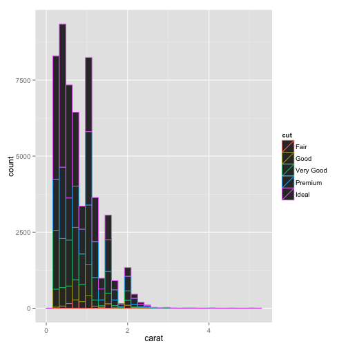

```r
qplot(carat, geom = "histogram", color = cut, data = d)
```

```
## stat_bin: binwidth defaulted to range/30. Use 'binwidth = x' to adjust this.
```

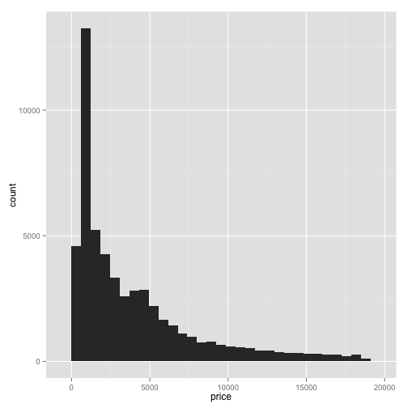

```r
qplot(price, geom = "histogram", data = d)
```

Now facet your histogram by clarity and cut.

[output not shown]

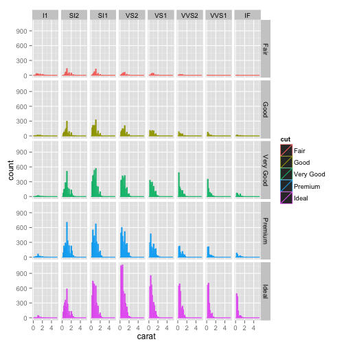

```r
qplot(carat, geom = "histogram", color = cut, facets = cut~ clarity, data = d)
```

[output not shown]

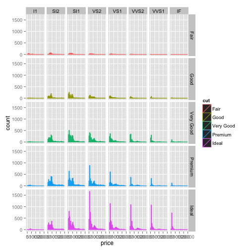

```r
qplot(price, geom = "histogram", color = cut, facets = cut~ clarity, data = d)
```

I like a slightly cleaner look to my plots. Luckily, ggplot allows you to add “themes” to your plots. Try doing the same plot but adding `+ theme_bw()` or `+ theme_classic()`. Different themes work better for different applications, in my experience.

[output not shown]

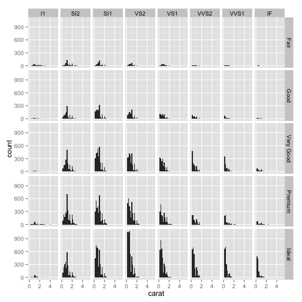

```r
qplot(carat, geom = "histogram", facets = cut~ clarity, data = d)
```

[output not shown]

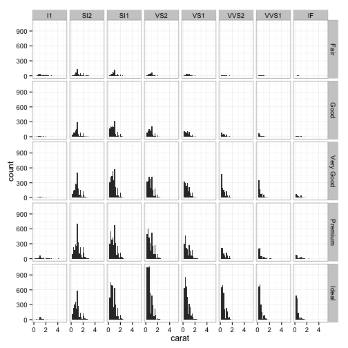

```r
qplot(carat, geom = "histogram", facets = cut~ clarity, data = d) + theme_bw()
```

[output not shown]

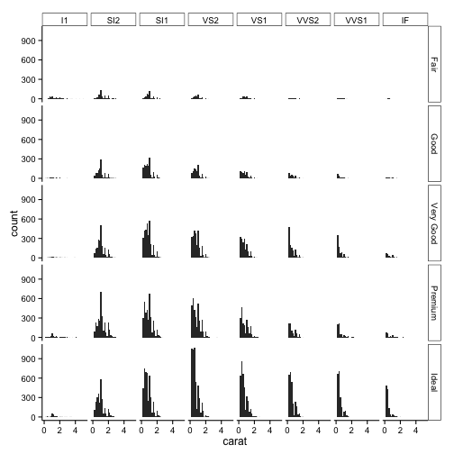

```r
qplot(carat, geom = "histogram", facets = cut~ clarity, data = d) + theme_classic()
```

## Part 1B: Exploring ggplot2 using ggplot

`ggplot` is just a way of building `qplot` calls up more systematically. It's sometimes easier to use and sometimes a bit more complicated. What I want to show off here is the functionality of being able to build up complex plots with multiple elements. You can actually do this using qplot pretty easily, but there are a few things that are hard to do.

`ggplot` is the basic call, where you specify A) a dataframe and B) an aesthetic mapping from variables in the plot space to variables in the dataset.

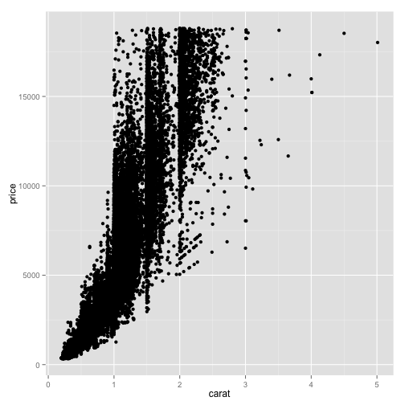

```r
d <- ggplot(diamonds, aes(x=carat, y=price)) # first you set the aesthetic and dataset
d + geom_point() # then you add geoms
```

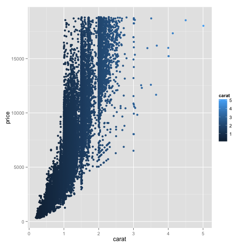

```r
d + geom_point(aes(colour = carat)) # and you can keep doing this to add layers to the plot
```

Try writing this as a single set of additions (e.g. one line of R code, though you can put in linebreaks). This is the most common workflow for me.

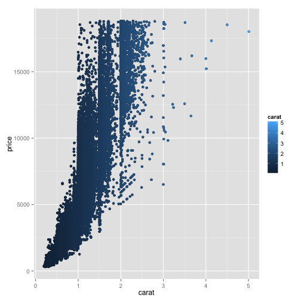

```r
ggplot(diamonds, aes(x=carat, y=price)) + geom_point() + geom_point(aes(colour=carat))
```

You can also set the aesthetic separately for each geom, and make some great plots this way. Though this can get complicated. Try using `ggplot` to build a histogram of prices.

```
## stat_bin: binwidth defaulted to range/30. Use 'binwidth = x' to adjust this.
## stat_bin: binwidth defaulted to range/30. Use 'binwidth = x' to adjust this.
```

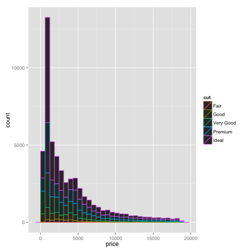

```r
ggplot(diamonds, aes(x=price)) + geom_histogram() + geom_histogram(aes(colour = cut))
```

# Part 2: Diving into real data: Sklar et al. (2012)

Sklar et al. (2012) claims evidence for unconscious arithmetic processing. We're going to do a reanalysis of their Experiment 6, which is the primary piece of evidence for that claim. The data are generously contributed by Asael Sklar.

First let's set up a few preliminaries.

```r
library(tidyr)
library(dplyr)
library(stringr)

sem <- function(x) {sd(x) / sqrt(length(x))}
ci95 <- function(x) {sem(x) * 1.96}
```

## Data Prep

First read in two data files and subject info. A and B refer to different trial order counterbalances.

```r
subinfo <- read.csv("../data/sklar_expt6_subinfo_corrected.csv")
d.a <- read.csv("../data/sklar_expt6a_corrected.csv")
d.b <- read.csv("../data/sklar_expt6b_corrected.csv")
```

Gather these datasets into long form and get rid of the Xs in the headers.

```r
d.a.tidy = gather(d.a, subjID, RT, X1:X21)
d.b.tidy = gather(d.b, subjID, RT, X22:X42)
```

Bind these together. Check out `bind_rows`.

```r
d.tidy = bind_rows(d.a.tidy, d.b.tidy)
d.eventidier = d.tidy %>% mutate(subid = str_sub(subjID, start = 2))
d.eventidier = select(d.eventidier, 1:7, RT, subid)
```

Merge these with subject info. You will need to look into merge and its relatives, `left_join` and `right_join`. Call this dataframe `d`, by convention.

```r
d.eventidier$subid = as.factor(d.eventidier$subid)
subinfo$subid = as.factor(subinfo$subid)
d = left_join(d.eventidier, subinfo)
```

Clean up the factor structure.

```r
d$presentation.time <- factor(d$presentation.time)
levels(d$operand) <- c("addition","subtraction")
```

## Data Analysis Preliminaries

Examine the basic properties of the dataset. First, take a histogram.

```
## stat_bin: binwidth defaulted to range/30. Use 'binwidth = x' to adjust this.
```

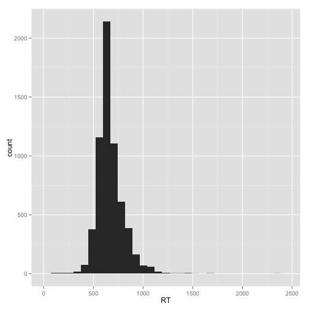

```r
d$RT = as.numeric(d$RT)
qplot(RT, data = d)
```

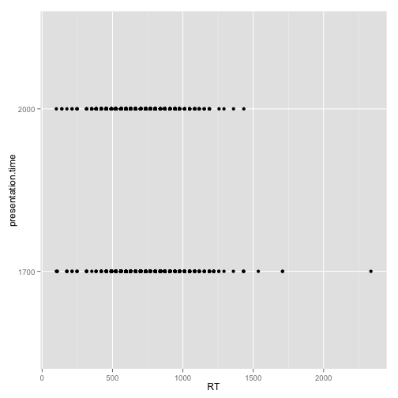

```r
qplot(RT, presentation.time, data = d)
```

Challenge question: what is the sample rate of the input device they are using to gather RTs?

30/second

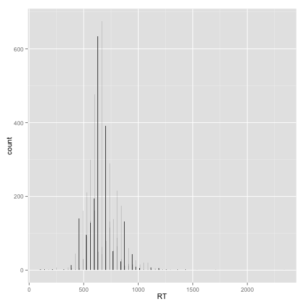

```r
qplot(RT, bin = 1, data = d)
```

Sklar et al. did two manipulation checks. Subjective - asking participants whether they saw the primes - and objective - asking them to report the parity of the primes (even or odd) to find out if they could actually read the primes when they tried. Examine both the unconscious and conscious manipulation checks (this information is stored in subinfo). What do you see? Are they related to one another?

```r
with(d, cor(subjective.test, objective.test))
```

```
## [1] 0.5786542
```

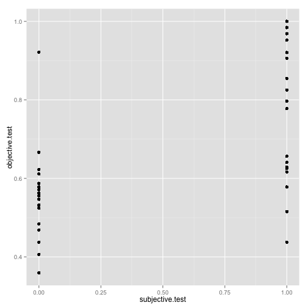

```r
with(d, qplot(subjective.test, objective.test))
```

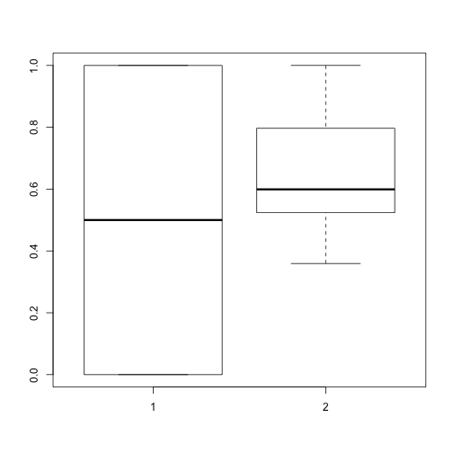

```r
with(d, boxplot(subjective.test, objective.test))
```

The conscious and unconscious manipulation checks are related (r=0.57). This seems to be borne out by the plots, which indicate that participants who said they did not see the prime were about at chance on the objective test, whereas those who said they did see the prime did better on the objective test.

OK, let's turn back to the measure and implement Sklar et al.'s exclusion criterion. You need to have said you couldn't see (subjective test) and also be not significantly above chance on the objective test (< .6 correct). Call your new data frame `ds`.

```r
ds = filter(d, subjective.test ==0, objective.test<0.6)
#ds = filter(ds, is.na(RT) == FALSE) #also removing the NA's becuase they were messing things up
```

## Sklar et al.'s analysis

Sklar et al. show a plot of a “facilitation effect” - the time to respond to incongruent primes minus the time to respond to congruent primes. They then show plot this difference score for the subtraction condition and for the two presentation times they tested. Try to reproduce this analysis.

HINT: first take averages within subjects, then compute your error bars across participants, using the `sem` function (defined above).

```r
dev.off()
```

```r
#qplot(congruent, RT, geom = "boxplot", facets = operand ~ presentation.time, na.rm = TRUE, data = ds) #ummm clearly not the right graph
#ds.sub = ds %>% group_by(subid, congruent)
#ds.sub.sum = summarise(ds.sub, mRT = mean(RT))
#ds %>% group_by(subid, congruent) %>% summarise(bet = mean(Answer_cost, na.rm=TRUE))
#ds.s = ds %>% group_by(subid) %>% mutate(subavg = mean(RT, na.rm = TRUE))

ds.s = ds %>% group_by(subid, congruent, presentation.time, operand) %>% mutate(rtavg = mean(RT, na.rm=TRUE))
#ds.s = ds.s %>% group_by(subid, operand) %>% summarise(rt.diff = identity(rtavg[congruent=="no"] - rtavg[congruent=="yes"]))
#ds.avg = ds.s %>% group_by(subid, operand) %>% do(rt.diff = .$rtavg[.$congruent=="no"] - .$rtavg[.$congruent=="yes"])
#ds.avg = ds.s %>% group_by(subid, operand) %>% mutate(rt.diff = filter(.$congruent =="no")$rtavg[[1]] - filter(.$congruent == "yes")$rtavg[[1]])
ds.avg = ds.s %>% group_by(subid, operand, presentation.time) %>% summarise(rt.diff = (rtavg[congruent =="no"]-rtavg[congruent=="yes"])[[1]])

ds.avg = ds.avg %>% group_by(presentation.time, operand) %>% mutate(sem = sem(rt.diff), n = n())

ds.f = ds.avg %>% group_by(presentation.time, operand) %>% summarise(rt = mean(rt.diff), sem = sem(rt.diff), n=n())

ds.new = ds %>% group_by(subid, congruent, presentation.time, operand) %>% summarise(rtavg = mean(RT, na.rm=TRUE)) %>% spread(congruent, rtavg) %>% mutate(rt.diff = no-yes) %>% group_by(presentation.time, operand) %>% summarise(avg.diff = mean(rt.diff), sem = sem(rt.diff), n=n()) #well, this way of doing things is much more elegant, but ultimately got me the same answer


#ummmm... doesn't look too different by condition... also why is it removing data??
#con_mean = ds %>% filter(congruent == "yes" %>% mean(.$RT)
#inc_mean = mean(filter(ds, congruent == "no")$RT)
```

Now plot this summary, giving more or less the bar plot that Sklar et al. gave (though I would keep operation as a variable here. Make sure you get some error bars on there (e.g. `geom_errorbar` or `geom_linerange`).

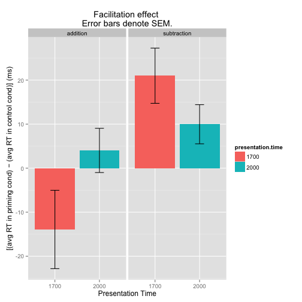

```r
#ggplot(ds.f, aes(x = presentation.time, y=rt)) + geom_bar(stat = "identity")

qplot(x=presentation.time, y=rt, facets = .~operand, data = ds.f, geom="bar", stat="identity", position = "dodge", fill = presentation.time) + geom_errorbar(aes(ymin = rt-sem, ymax = rt+sem), width = 0.2) + xlab("Presentation Time") + ylab("[(avg RT in priming cond) − (avg RT in control cond)] (ms)") + ggtitle("Facilitation effect \nError bars denote SEM.")
```

```r
#qplot(operand, rt.diff, data = ds.avg)
#qplot(x=operand, y=rt.diff, geom = "bar", stat = "identity", position = "dodge", data = ds.avg)

#ggplot(ds.avg, aes(x = presentation.time, y=rt.diff)) + geom_bar(stat = "identity") + theme_grey()
```

What do you see here? How close is it to what Sklar et al. report? Do the error bars match? How do you interpret these data?

Looks pretty similar, except their SEM error bars are about half as large as my SEM error bars.

Challenge problem: verify Sklar et al.'s claim about the relationship between RT and the objective manipulation check.

## Your own analysis

Show us what you would do with these data, operating from first principles. What's the fairest plot showing a test of Sklar et al.'s original hypothesis that people can do arithmetic “non-consciously”?

Challenge problem: Do you find any statistical support for Sklar et al.'s findings?